Skip to main content

# Accessible Course Document Template

- Show All Code
- Hide All Code
- View Source

Title II ADA Compliant Configuration

Author

Professor Name

Published

October 5, 2026

## Document Structure (Headings)

To comply with **ADA Title II (WCAG 2.1/2.2 Level AA)**, your document must follow a logical, nesting hierarchy. Screen readers rely entirely on heading tags to build a page index for navigation.

- Always use structural headers sequentially (`## Heading 2`, `### Heading 3`).
- **Never** skip a heading level (e.g., jumping from `## Heading 2` directly to `#### Heading 4`).
- **Never** use bold text variations (`**Text**`) just to make a line look like a section title; screen readers will not recognize it as a page landmark.

## Computational Outputs & Tables

Do not print raw R console outputs (like basic matrix printouts) for tables, as screen readers cannot interpret them semantically. Use accessible layout packages like `knitr::kable` or `gt` to automatically generate semantic HTML structure (`<table>`, `<th>`, `<tr>`, `<td>`).

```r
library(knitr)

# Sample compliant data frame
course_data <- data.frame(
  `Course Name` = c("Introduction to Data Science", "Applied Biostatistics"),
  `Enrolled Students` = c(45, 28),
  `Passing Rate` = c("92%", "88%"),
  check.names = FALSE
)

# kable automatically injects accessible HTML table wrappers
knitr::kable(course_data)
```

Table 1: Table 1: Fall Enrollment and Final Performance Demographics.

| Course Name | Enrolled Students | Passing Rate |
| --- | --- | --- |
| Introduction to Data Science | 45 | 92% |
| Applied Biostatistics | 28 | 88% |

## Data Visualizations & Alt Text

Every chart, plot, or image **must** include an explicit alternative text description (`fig-alt`). The text should concisely convey the point of the visualization rather than just stating “a plot”.

Additionally, use a colorblind-friendly palette (such as Viridis) to guarantee compliance with WCAG Level AA color contrast ratios (minimum **4.5:1** for normal text, **3:1** for graphical elements).

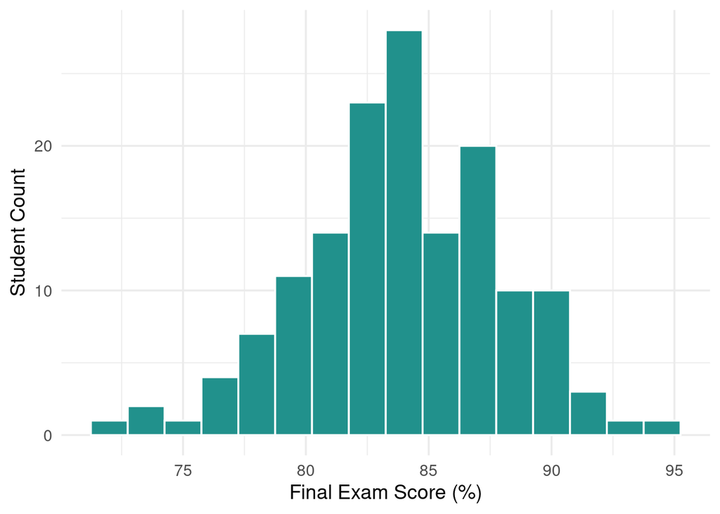

Figure 1: Figure 1: Distribution of final exam scores across sections.

```r
library(ggplot2)

# Generate dummy normal data
set.seed(42)
scores <- data.frame(grade = rnorm(150, mean = 84, sd = 4))

# Plotting using the colorblind-friendly scale
ggplot(scores, aes(x = grade)) +
  geom_histogram(binwidth = 1.5, fill = "#21918c", color = "#ffffff") +
  theme_minimal(base_size = 14) + # Boost base font size for readability
  labs(
    x = "Final Exam Score (%)",
    y = "Student Count"
  )
```

## Form Accessibility

If this document serves as an assignment, ensure form fields or activity spaces are cleanly separated. Provide descriptive instructions instead of color-coded prompts (e.g., avoid “Answer the question highlighted in red”).